# ETC3250/5250 IML Asignment 1

Yunzhi Chen (32051018)

2023-04-03

```r
# Load the packages that you will use to complete this assignment.
library(tidyverse)
library(lubridate)
library(GGally)
library(rsample)
library(broom)
library(tidymodels)
library(glmnet)
set.seed(32051018)
```

## A. Preliminary analysis

*1. Load your downloaded data into R as a `tibble` object, ensuring each variable is encoded appropriately, and display the first 10 rows of your data set.* **(1 mark)**

```r
mydata <- read_csv(here::here("Assignment1/data32051018.csv")) %>%
  as_tibble() %>%
  mutate(open_date = as.Date(open_date, "%m/%d/%Y"))
head(mydata, 10)
```

```
## # A tibble: 10 x 12
##       id open_date  type     P1    P2    P3    P4    P5    P6    P7    P8
##    <dbl> <date>     <chr> <dbl> <dbl> <dbl> <dbl> <dbl> <dbl> <dbl> <dbl>
##  1 39624 2009-11-26 IL        3   4       6     5     0     5     5   5
##  2 37822 2009-12-16 FC        5   4       5     5     4     1     5   5
##  3 83055 2008-04-04 IL        3   4       2     5     4    25     8   4
##  4 97835 2010-05-07 FC        4   3       1     4     0     4     5   4.5
##  5 63792 2007-05-05 FC        1   7.5    12    10     0     5     5   5
##  6 85184 2013-07-31 IL        4   4       2     5     3     5    10   4
##  7 95677 2013-07-12 FC        5   6       4     5     4     1     4   4.5
##  8 72430 1998-02-26 IL        3   4       4     4     0     5     5   3
##  9 40851 2011-05-18 FC        1   4       4     4     3     4     5   3
## 10 65346 2011-10-15 IL        4   4       3     5     0     5     4   5
## # ... with 1 more variable: revenue <dbl>
```

*2. Construct a new variable called `age` that corresponds to the age of the restaurant (in years) at 1st January, 2015. Show the histogram of this `age` variable.* **(1 mark)**

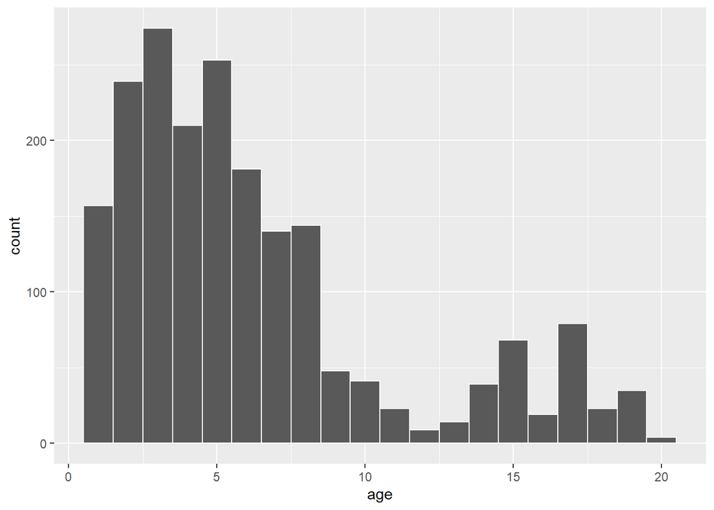

```r
mydata_age <- mydata %>%
  mutate(age = as.Date("01/01/2015", "%m/%d/%Y") - open_date)

mydata_age <- mydata_age %>%
  mutate(age = round(time_length(age, unit = "year"), 2))

mydata_age %>%
  ggplot(aes(x = age)) +
  geom_histogram(binwidth = 1, colour = "white")
```

*3. Produce a pair-wise scatter plot of each *numerical* variable against the response. What do you notice from the plot? Make another plot for each of the numerical variable against the response that better shows the relationship between the two variables.* **(2 marks)**

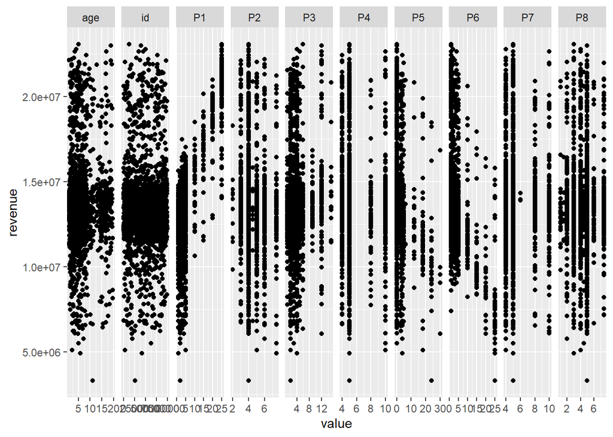

```r
# Plot1
mydata_num <- mydata_age %>%
  select(
    -open_date,
    -type
  )

mydata_num %>%
  pivot_longer(-revenue,
    names_to = "factor",
    values_to = "value"
  ) %>%
  ggplot(aes(
    x = value,
    y = revenue
  )) +
  geom_point() +
  facet_grid(. ~ factor, scales = "free_x")
```

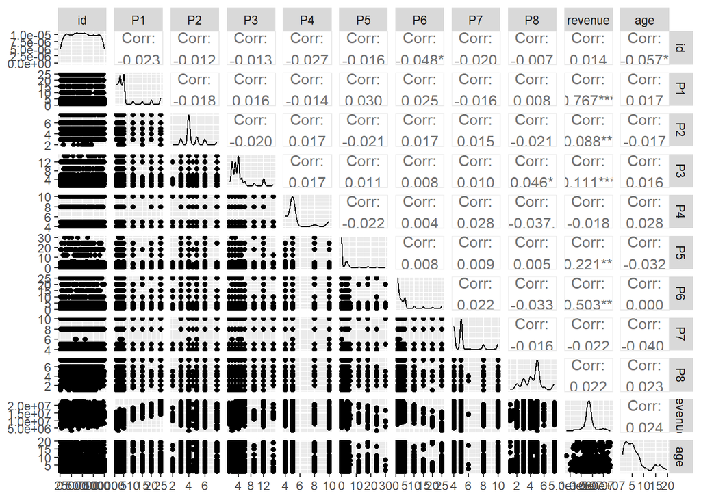

```r
# Plot2
GGally::ggpairs(mydata_num)
```

*4. Produce a numerical summary of all the variables in the data set.* **(1 mark)**

```r
summary(mydata_num)
```

```
##        id              P1               P2              P3
##  Min.   :   32   Min.   : 1.000   Min.   :2.000   Min.   : 1.000
##  1st Qu.:25092   1st Qu.: 2.000   1st Qu.:4.000   1st Qu.: 2.000
##  Median :49283   Median : 3.000   Median :4.000   Median : 4.000
##  Mean   :49723   Mean   : 5.276   Mean   :4.432   Mean   : 4.093
##  3rd Qu.:74426   3rd Qu.: 5.000   3rd Qu.:5.000   3rd Qu.: 4.000
##  Max.   :99935   Max.   :25.000   Max.   :7.500   Max.   :15.000
##        P4               P5               P6               P7
##  Min.   : 4.000   Min.   : 0.000   Min.   : 1.000   Min.   : 4.000
##  1st Qu.: 5.000   1st Qu.: 0.000   1st Qu.: 1.000   1st Qu.: 4.000
##  Median : 5.000   Median : 0.000   Median : 2.000   Median : 5.000
##  Mean   : 5.473   Mean   : 2.092   Mean   : 3.751   Mean   : 5.257
##  3rd Qu.: 5.000   3rd Qu.: 3.000   3rd Qu.: 4.000   3rd Qu.: 5.000
##  Max.   :10.000   Max.   :30.000   Max.   :25.000   Max.   :10.000
##        P8           revenue              age
##  Min.   :1.000   Min.   : 3300819   Min.   : 0.990
##  1st Qu.:3.000   1st Qu.:12519175   1st Qu.: 2.920
##  Median :5.000   Median :13405963   Median : 5.110
##  Mean   :4.402   Mean   :13629705   Mean   : 6.288
##  3rd Qu.:5.000   3rd Qu.:14339920   3rd Qu.: 7.700
##  Max.   :7.500   Max.   :23059810   Max.   :19.650
```

*5. Using the preliminary exploration in questions 1 to 4, do you observe any patterns in the data? Should you use the variable `id` and `open_date` in your predictive model? Explain your answer.* **(2 marks)**

The pair plot illustrates that P1, P5, and P6 are significantly correlated with revenue. Besides, it seems that there is no relationship between id/age and revenue. The revenue is bell-shaped, which indicates it is a normal distribution. I do not think I can involve the variable `id` and `open_date` in my predictive model, as those two variables are not significantly correlated with revenue.

### B Regression

*1. Remove the variables `id` and `open_date` from the data and select 70% of the observations to be used as the training data and the remaining data as the testing data.* **(1 mark)**

```r
restaurants <- mydata %>%
  select(
    -open_date,
    -id
  )

restaurants_split <- initial_split(restaurants, prop = 0.7)
restaurants_train <- training(restaurants_split)
restaurants_test <- testing(restaurants_split)
```

*2. Use the training sample to estimate a multiple linear regression model for `revenue` in terms of all the predictors. Show the summary of this model fit. Discuss how well this model fits the data.* **(2 marks)**

```r
fit_all <- lm(revenue ~ .,
  data = restaurants_train
)

summary(fit_all)
```

```
##
## Call:
## lm(formula = revenue ~ ., data = restaurants_train)
##
## Residuals:
##      Min       1Q   Median       3Q      Max
## -2417983  -264495  -132260   286749  3936726
##
## Coefficients:
##             Estimate Std. Error t value Pr(>|t|)
## (Intercept) 13268304     184096  72.073   <2e-16 ***
## typeFC         84433     142958   0.591    0.555
## typeIL         78936     143979   0.548    0.584
## P1            342912       3003 114.191   <2e-16 ***
## P2           -136851      15842  -8.638   <2e-16 ***
## P3             99730       6256  15.942   <2e-16 ***
## P4             -9769       9980  -0.979    0.328
## P5           -145904       3935 -37.076   <2e-16 ***
## P6           -272179       3483 -78.148   <2e-16 ***
## P7             12616      10038   1.257    0.209
## P8             -7159      12115  -0.591    0.555
## ---
## Signif. codes:  0 '***' 0.001 '**' 0.01 '*' 0.05 '.' 0.1 ' ' 1
##
## Residual standard error: 659700 on 1389 degrees of freedom
## Multiple R-squared:  0.9342, Adjusted R-squared:  0.9337
## F-statistic:  1973 on 10 and 1389 DF,  p-value: < 2.2e-16
```

```r
glance(fit_all)
```

```
## # A tibble: 1 x 12
##   r.squared adj.r.s~1  sigma stati~2 p.value    df  logLik    AIC    BIC devia~3
##       <dbl>     <dbl>  <dbl>   <dbl>   <dbl> <dbl>   <dbl>  <dbl>  <dbl>   <dbl>
## 1     0.934     0.934 6.60e5   1973.       0    10 -20740. 41505. 41568. 6.04e14
## # ... with 2 more variables: df.residual <int>, nobs <int>, and abbreviated
## #   variable names 1: adj.r.squared, 2: statistic, 3: deviance
```

As R2 is 0.934, the model explains about almost all the variation in revenue. Which means, it is a strongly well-fitting model.

*3. Consider a model for `revenue` with all predictors *except* `type`. Show the summary of this model fit. Compare this model with the fitted model in question B2 using a hypothesis test. Explain the results of this test.* **(3 marks)**

```r
restaurants_train_notype <-
  restaurants_train %>%
  select(-type)

fit_notype <- lm(revenue ~ .,
  data = restaurants_train_notype
)

summary(fit_notype)
```

```
##
## Call:
## lm(formula = revenue ~ ., data = restaurants_train_notype)
##
## Residuals:
##      Min       1Q   Median       3Q      Max
## -2421265  -265167  -134474   289974  3939400
##
## Coefficients:
##             Estimate Std. Error t value Pr(>|t|)
## (Intercept) 13348478     121978 109.434   <2e-16 ***
## P1            342869       3000 114.277   <2e-16 ***
## P2           -137015      15820  -8.661   <2e-16 ***
## P3             99892       6244  15.999   <2e-16 ***
## P4             -9805       9961  -0.984    0.325
## P5           -145971       3931 -37.132   <2e-16 ***
## P6           -272212       3480 -78.213   <2e-16 ***
## P7             12831      10024   1.280    0.201
## P8             -7073      12096  -0.585    0.559
## ---
## Signif. codes:  0 '***' 0.001 '**' 0.01 '*' 0.05 '.' 0.1 ' ' 1
##
## Residual standard error: 659300 on 1391 degrees of freedom
## Multiple R-squared:  0.9342, Adjusted R-squared:  0.9338
## F-statistic:  2469 on 8 and 1391 DF,  p-value: < 2.2e-16
```

```r
anova(fit_all, fit_notype)
```

```
## Analysis of Variance Table
##
## Model 1: revenue ~ type + P1 + P2 + P3 + P4 + P5 + P6 + P7 + P8
## Model 2: revenue ~ P1 + P2 + P3 + P4 + P5 + P6 + P7 + P8
##   Res.Df        RSS Df   Sum of Sq      F Pr(>F)
## 1   1389 6.0445e+14
## 2   1391 6.0460e+14 -2 -1.5558e+11 0.1788 0.8363
```

As can be seen from the Analysis of Variance Table, some of the important columns are:

- Df: represents the degrees of freedom in the model.
- Sum Sq: represents the residual sum of squares.
- F value: the value of the F statistic used to test for differences between the models.
- Pr(>F): the p-value of the F statistic used to determine whether the differences between the models are significant.

*4. Which of the two regression models considered (in questions B2 and B3) is best at predicting new records? Explain your answer.* **(2 marks)**

### C Subset selection

*1. Consider the model in question B2 as the full model. Perform a backward elimination using BIC. Report the final selected model using this process.* **(2 marks)**

```r
backward <- stats::step(fit_all,
  scope = list(
    lower = revenue ~ 1,
    upper = formula(fit_all)
  ),
  direction = "backward",
  k = log(nrow(restaurants_train))
)
```

```
## Start:  AIC=37587.24
## revenue ~ type + P1 + P2 + P3 + P4 + P5 + P6 + P7 + P8
##
##        Df  Sum of Sq        RSS   AIC
## - type  2 1.5558e+11 6.0460e+14 37573
## - P8    1 1.5194e+11 6.0460e+14 37580
## - P4    1 4.1700e+11 6.0487e+14 37581
## - P7    1 6.8748e+11 6.0514e+14 37582
## <none>               6.0445e+14 37587
## - P2    1 3.2472e+13 6.3692e+14 37653
## - P3    1 1.1059e+14 7.1504e+14 37815
## - P5    1 5.9820e+14 1.2026e+15 38543
## - P6    1 2.6576e+15 3.2621e+15 39940
## - P1    1 5.6745e+15 6.2789e+15 40857
##
## Step:  AIC=37573.11
## revenue ~ P1 + P2 + P3 + P4 + P5 + P6 + P7 + P8
##
##        Df  Sum of Sq        RSS   AIC
## - P8    1 1.4862e+11 6.0475e+14 37566
## - P4    1 4.2116e+11 6.0502e+14 37567
## - P7    1 7.1214e+11 6.0532e+14 37568
## <none>               6.0460e+14 37573
## - P2    1 3.2604e+13 6.3721e+14 37639
## - P3    1 1.1126e+14 7.1587e+14 37802
## - P5    1 5.9930e+14 1.2039e+15 38530
## - P6    1 2.6589e+15 3.2635e+15 39926
## - P1    1 5.6763e+15 6.2809e+15 40843
##
## Step:  AIC=37566.21
## revenue ~ P1 + P2 + P3 + P4 + P5 + P6 + P7
##
##        Df  Sum of Sq        RSS   AIC
## - P4    1 3.9615e+11 6.0515e+14 37560
## - P7    1 7.3446e+11 6.0549e+14 37561
## <none>               6.0475e+14 37566
## - P2    1 3.2570e+13 6.3732e+14 37632
## - P3    1 1.1114e+14 7.1589e+14 37795
## - P5    1 5.9924e+14 1.2040e+15 38523
## - P6    1 2.6597e+15 3.2645e+15 39919
```

[output cut: 9 more lines]

```
## - P3    1 1.1125e+14 7.1639e+14 37789
## - P5    1 5.9894e+14 1.2041e+15 38516
## - P6    1 2.6624e+15 3.2676e+15 39913
## - P1    1 5.6780e+15 6.2832e+15 40829
##
## Step:  AIC=37554.3
## revenue ~ P1 + P2 + P3 + P5 + P6
##
##        Df  Sum of Sq        RSS   AIC
## <none>               6.0587e+14 37554
## - P2    1 3.2601e+13 6.3847e+14 37620
## - P3    1 1.1138e+14 7.1725e+14 37783
## - P5    1 5.9854e+14 1.2044e+15 38509
## - P6    1 2.6617e+15 3.2676e+15 39906
## - P1    1 5.6778e+15 6.2837e+15 40822
```

Through backward elimination using BIC, it can be concluded that the final selected model is having P1, P2, P3, P5, and P6 as predictors(revenue ~ P1 + P2 + P3 + P5 + P6) as this model has the lowest AIC value, which is AIC=37554.3.

*2. Again consider the same model question B2 and perform now a step-wise regression using AIC. How is this model different to the one selected in question C1?* **(2 marks)**

```r
stepwise <- stats::step(fit_all,
  scope = list(
    lower = revenue ~ 1,
    upper = formula(fit_all)
  ),
  direction = "both",
  k = 2
)
```

```
## Start:  AIC=37529.55
## revenue ~ type + P1 + P2 + P3 + P4 + P5 + P6 + P7 + P8
##
##        Df  Sum of Sq        RSS   AIC
## - type  2 1.5558e+11 6.0460e+14 37526
## - P8    1 1.5194e+11 6.0460e+14 37528
## - P4    1 4.1700e+11 6.0487e+14 37529
## - P7    1 6.8748e+11 6.0514e+14 37529
## <none>               6.0445e+14 37530
## - P2    1 3.2472e+13 6.3692e+14 37601
## - P3    1 1.1059e+14 7.1504e+14 37763
## - P5    1 5.9820e+14 1.2026e+15 38491
## - P6    1 2.6576e+15 3.2621e+15 39888
## - P1    1 5.6745e+15 6.2789e+15 40804
##
## Step:  AIC=37525.91
## revenue ~ P1 + P2 + P3 + P4 + P5 + P6 + P7 + P8
##
##        Df  Sum of Sq        RSS   AIC
## - P8    1 1.4862e+11 6.0475e+14 37524
## - P4    1 4.2116e+11 6.0502e+14 37525
## - P7    1 7.1214e+11 6.0532e+14 37526
## <none>               6.0460e+14 37526
## + type  2 1.5558e+11 6.0445e+14 37530
## - P2    1 3.2604e+13 6.3721e+14 37597
## - P3    1 1.1126e+14 7.1587e+14 37760
## - P5    1 5.9930e+14 1.2039e+15 38488
## - P6    1 2.6589e+15 3.2635e+15 39884
## - P1    1 5.6763e+15 6.2809e+15 40801
##
## Step:  AIC=37524.26
## revenue ~ P1 + P2 + P3 + P4 + P5 + P6 + P7
##
##        Df  Sum of Sq        RSS   AIC
## - P4    1 3.9615e+11 6.0515e+14 37523
## - P7    1 7.3446e+11 6.0549e+14 37524
## <none>               6.0475e+14 37524
## + P8    1 1.4862e+11 6.0460e+14 37526
## + type  2 1.5226e+11 6.0460e+14 37528
## - P2    1 3.2570e+13 6.3732e+14 37596
```

[output cut: 19 more lines]

```
##
## Step:  AIC=37522.84
## revenue ~ P1 + P2 + P3 + P5 + P6
##
##        Df  Sum of Sq        RSS   AIC
## <none>               6.0587e+14 37523
## + P7    1 7.1900e+11 6.0515e+14 37523
## + P4    1 3.8069e+11 6.0549e+14 37524
## + P8    1 1.4430e+11 6.0572e+14 37525
## + type  2 1.8057e+11 6.0569e+14 37526
## - P2    1 3.2601e+13 6.3847e+14 37594
## - P3    1 1.1138e+14 7.1725e+14 37757
## - P5    1 5.9854e+14 1.2044e+15 38483
## - P6    1 2.6617e+15 3.2676e+15 39880
## - P1    1 5.6778e+15 6.2837e+15 40796
```

By using step-wise regression, the best model is revenue ~ P1 + P2 + P3 + P5 + P6, which has the AIC value to be 37522.84. There is no difference of the result that chosen by stepwise regression and backward regression. In fact, stepwise regression is a combination of both forward and backward selection, it can be more efficient in selecting variables. However, it can also be prone to overfitting the model.

### D Regularization

*1. Make an appropriate transformation to the training data for regularization methods. From this transformed training dataset, create a 5-fold cross validation dataset.* **(2 marks)**

```r
# recipe
restaurants_recipe <- recipe(revenue ~ .,
  data = restaurants_train
) %>%
  step_normalize(all_numeric_predictors()) %>%
  step_dummy(all_nominal_predictors()) %>%
  step_zv(all_predictors()) %>%
  step_log(all_outcomes(), base = 10) %>%
  prep()

restaurants_recipe
```

```
## -- Recipe ----------------------------------------------------------------------
```

```
## -- Inputs
```

```
## Number of variables by role
```

```
## outcome:   1
## predictor: 9
```

```
## -- Training information
```

```
## Training data contained 1400 data points and no incomplete rows.
```

```
## -- Operations
```

```
## * Centering and scaling for: P1, P2, P3, P4, P5, P6, P7, P8 | Trained
```

```
## * Dummy variables from: type | Trained
```

```
## * Zero variance filter removed: <none> | Trained
```

```
## * Log transformation on: revenue | Trained
```

```r
# bake
restaurants_train <- restaurants_recipe %>%
  bake(new_data = NULL)

restaurants_test <- restaurants_recipe %>%
  bake(new_data = restaurants_test)
# 5-fold cross validation
restaurants_folds <- vfold_cv(restaurants_train, v = 5)
```

*2. Using the dataset from question D1, select the optimal tuning parameter $\lambda$ for lasso regression using the average root mean square error. You can use the search range for $\lambda$ to be $[1, 10^{10}]$ (or in code use `10^seq(0, 10, length = 50)`). You should *not* use any convenience function like `cv.glmnet` to select $\lambda$.* **(2 marks)**

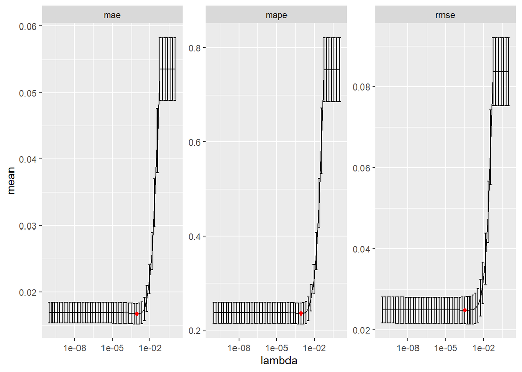

```r
select <- dplyr::select

lambda_vec <- 10^seq(-10, 0, length = 50)

cv_glmnet_to_restaurants <- function(alpha) {
  restaurants_folds %>%
    mutate(metrics = map(splits, function(.split) {
      fold_train_data <- training(.split)
      fold_fit <- glmnet(
        x = fold_train_data %>%
          select(-revenue),
        y = fold_train_data$revenue,
        alpha = alpha,
        lambda = lambda_vec
      )

      fold_test_data <- testing(.split)

      fold_preds <- fold_fit %>%
        predict(as.matrix(select(fold_test_data, -revenue))) %>%
        as.data.frame() %>%
        add_column(revenue = fold_test_data$revenue) %>%
        pivot_longer(-revenue, values_to = ".pred", names_to = "name") %>%
        left_join(tibble(
          name = paste0("s", 1:length(lambda_vec) - 1),
          lambda = rev(lambda_vec)
        ),
        by = "name"
        )

      fold_preds %>%
        group_by(name, lambda) %>%
        metric_set(rmse, mae, mape)(., revenue, .pred) %>%
        select(-.estimator) %>%
        arrange(.metric, lambda)
    })) %>%
    unnest(metrics) %>%
    group_by(name, .metric) %>%
    summarise(
      lambda = unique(lambda),
      mean = mean(.estimate),
      se = sd(.estimate)
    )
}

restaurants_lasso_tuning <- cv_glmnet_to_restaurants(alpha = 1)

restaurants_lasso_tuning_min <- restaurants_lasso_tuning %>%
  group_by(.metric) %>%
  filter(mean == min(mean))

restaurants_lasso_tuning %>%
  ggplot(aes(lambda, mean)) +
  geom_errorbar(aes(
    ymin = mean - se,
    ymax = mean + se
  )) +
  geom_line() +
  geom_point(
    data = restaurants_lasso_tuning_min,
    color = "red"
  ) +
  facet_wrap(~.metric, scale = "free_y") +
  scale_x_log10()
```

```r
best_lambda_lasso <- restaurants_lasso_tuning_min$lambda[3]

best_lambda_lasso
```

```
## [1] 0.0003393222
```

*3. Fit an elastic net model with optimal $\lambda$ and $\alpha$ selected by cross validation root mean square error using the dataset from question D2. Recall that $\alpha \in [0, 1]$ (in code you can use `seq(0, 1, length = 21)`). Remember that you need to find a combination of $\lambda$ and $\alpha$ that minimises the average root mean square error. Again don’t use any convenience (i.e. one line) function. Discuss the results.* **(4 marks)**

```r
select <- dplyr::select

alpha_vec <- seq(0, 1, length = 21)
results <- data.frame(
  alpha = alpha_vec,
  lambda = numeric(length(alpha_vec)),
  mean = numeric(length(alpha_vec)),
  se = numeric(length(alpha_vec))
)

for (alpha in alpha_vec) {
  restaurants_elastic_tuning <- cv_glmnet_to_restaurants(alpha)

  restaurants_elastic_tuning_min <- restaurants_elastic_tuning %>%
    group_by(.metric) %>%
    filter(mean == min(mean))


  results$lambda[which(alpha_vec == alpha)] <- restaurants_elastic_tuning_min$lambda
  results$mean[which(alpha_vec == alpha)] <- restaurants_elastic_tuning_min$mean
  results$se[which(alpha_vec == alpha)] <- restaurants_elastic_tuning_min$se
}

best_lambda_alpha <- results %>%
  filter(mean == min(mean))

best_lambda_alpha
```

```
##   alpha      lambda      mean          se
## 1  0.55 0.001389495 0.0166937 0.001552785
```

## E. Conclusion

*1. What variables are important (or not important) in modelling the response? Explain your answer.* **(2 marks)**

From the previous analysis, it is clear that for the model, it is important to have the variables of P1, P2, P3, P5, P6 (obfuscated variables that are either demographic, real estate, or commercial information related to the restaurant). On the other hand, the id, type, and open_date are not important for the model.

*2. What model would you recommend to TFI for predicting new records? Give statistical reasons for your recommendation.* **(2 marks)**

```r
best_fit <- glmnet(
  x = restaurants_train %>%
    select(-revenue),
  y = restaurants_train$revenue,
  alpha = 0.55,
  lambda = 0.001389495
)
```